# Question

Carmen necesita calcular el valor del cateto x en el triángulo rectángulo de la imagen.

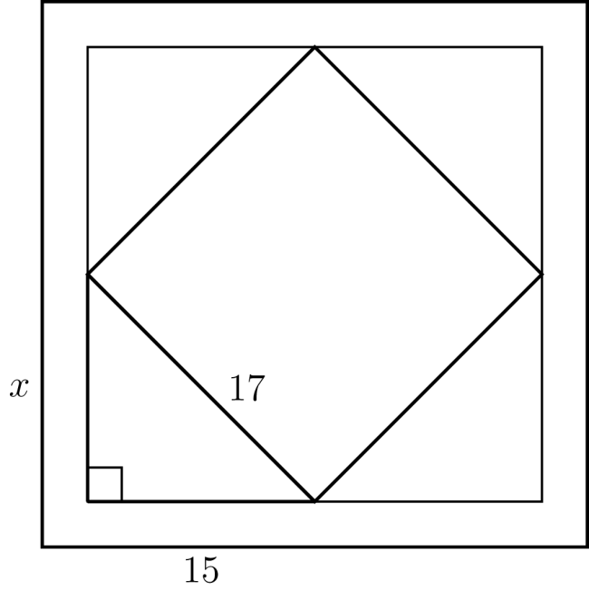

Para esto, efectúa correctamente el siguiente procedimiento:

**Paso 1.** Calcula la hipotenusa $\sqrt{x^2 + 15^2}$ y obtiene $17$.

**Paso 2.** El resultado del paso 1 lo eleva al cuadrado y obtiene como resultado el número 289.

¿Cuál es el valor del cateto $x$?

## Answerlist

- $x = 30$
- $x = 64$
- $x = 8$
- $x = 2$

# Solution

Para resolver este problema, debemos analizar la información geométrica y aplicar el teorema de Pitágoras correctamente.

**Análisis de la figura:**

- El cuadrado exterior contiene el triángulo rectángulo
- El triángulo rectángulo tiene catetos de longitud $x$ y $15$
- La hipotenusa del triángulo es $17$

**Resolución paso a paso:**

Del **Paso 1**: $\sqrt{x^2 + 15^2} = 17$

Del **Paso 2**: $(17)^2 = 289$

Verificamos el **Paso 2**: $(17)^2 = 289$ (correcto)

Sustituyendo en la ecuación del **Paso 1**: $x^2 + 15^2 = 289$

Resolviendo: $x^2 + 225 = 289$

Por lo tanto: $x^2 = 289 - 225 = 64$

Para este ejercicio específico:

$$x^2 = 289 - 225 = 64$$

Entonces:
$$x = \sqrt{ 64 } = 8$$

**Verificación geométrica:** Si $x = 8$, entonces $\sqrt{(8)^2 + (15)^2} = \sqrt{64 + 225} = \sqrt{289} = 17$

Y $(17)^2 = 289$ (verificado)

## Answerlist

- Falso. Error: duplica el cateto conocido
- Falso. Error: olvida aplicar raíz cuadrada
- Verdadero. Aplicando correctamente el teorema de Pitágoras: x² + 225 = 289 , por lo tanto x = 8
- Falso. Error: resta simple sin teorema

# Meta-information

exname: Cateto triangulo rectangulo teorema Pitagoras extype: schoice exsolution: 0010 exshuffle: TRUE exsection: Geometria/Teorema de Pitagoras

# Metadatos ICFES obligatorios

icfes: competencia: formulacion_ejecucion nivel_dificultad: 2 contenido: categoria: geometria tipo: generico contexto: matematico eje_axial: eje2 componente: geometrico_metrico